# PIERS Data Cleaning

This notebook addresses missing data and other issues in the PIERS BOL data. This work is predominantly exploratory in nature, and some of these processes may eventually move to the ETL step.

Convenience steps:

- create 2-digit hs codes (note this naievely takes the first two digits from the column, which contains multiple hs codes)
- create year and month (e.g., 202305) columns
- replace zero values with nulls in volume columns
- create voyage_id from year, vessel IMO code, voyage number, and origin/destination country
- add direction column showing 'import' or 'export' to allow easy merging
- get most commonly used SCAC and name for each carrier

## Notebook functions

## Missing Data

```
Missing Values Matrix for Exports.
The vertical axis corresponds to date, with earliest at the top.
Note the daily aggregation counts the row as non-null if any value that day is non-null.
```

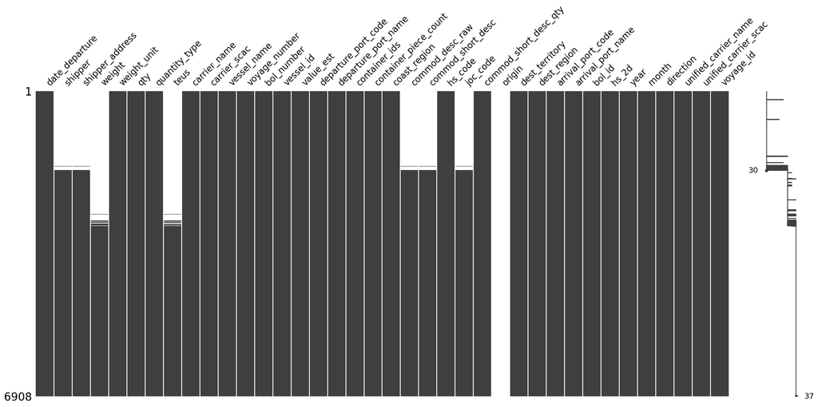

[output not shown]

### Zero values in TEU and other volume columns

For the time being, we fill the zero (i.e., missing) volume data with the mean from non-zero observations. This step is expected to change as beter metadata is gathered.

## Primary Carrier

For any given voyage, we assign primary carrier based on the proportion of TEUs from each carrier imported/exported on that voyage (max proportion is primary carrier).

## Days in port

For each arrival, we want to know how many days the ship stays in port before departing.

### 'BULK' Carrier SCAC

Many bols show "BULK" in place of carrier code, and at least some bols also show legitimate carrier names. We'll need to clean this up. Perhaps assign carrier code based on carrier name where possible and null values for the reminder?

## Export Clean data to parquet